# Длительность прохождения и посещение форума

## 1. Об отчете

### Исследовательские вопросы

1. Как длительность прохождения курса влияет на число посещенных страниц форума?
2. Как число посещенных страниц форума варьируется в зависимости от курса?
3. Как нормализованная длительность прохождения курса влияет на нормализованное посещение форума?

## Описание переменных

- *vis_p* - индивидуальное посещение форума;
- *duration* - индивидуальная длительность прохождения курса в днях;
- *vis_p_n* - нормализованное посещение = индивидуальное посещение форума / среднее посещение форума на курсе;
- *duration_n* - нормализованное прохождение = индивидуальная длительность прохождения курса / среднее посещение форума на курсе;

## 1. Влияние количества посещенных страниц на длительность прохождения курса

Выбор статистических инструментов:

1. Переменная vis_p счетная, для таких переменных используется пуассоновское или отрицательно-биномиальное распределение.
2. how extra-Poisson variation (i.e., overdispersion), odTest(), поможет нам выбрать необходимое распределение. Оно проверяет верно ли необходимое условие для использование Пуассоновской регрессии - равенство условного среднего и условного распределения. Если значение p-value меньше 0.05, то гипотеза о чрезмерной дисперсии не может быть отброшена. В таком случае следует применять отрицательно-биномиальное распределение.

```r
m1 <-  glm.nb(duration ~ vis_p_n, students)
od <- odTest(m1)
```

```
## Likelihood ratio test of H0: Poisson, as restricted NB model:
## n.b., the distribution of the test-statistic under H0 is non-standard
## e.g., see help(odTest) for details/references
##
## Critical value of test statistic at the alpha= 0.05 level: 2.7055
## Chi-Square Test Statistic =  1482395.0381 p-value = < 2.2e-16
```

```r
m1 <- glm.nb(duration ~ vis_p, students)
summary(m1)
```

```
##
## Call:
## glm.nb(formula = duration ~ vis_p, data = students, init.theta = 0.8861861438,
##     link = log)
##
## Deviance Residuals:
##     Min       1Q   Median       3Q      Max
## -2.6608  -1.0137  -0.2178   0.4068   3.1699
##
## Coefficients:
##              Estimate Std. Error z value Pr(>|z|)
## (Intercept) 3.737e+00  5.481e-03  681.78   <2e-16 ***
## vis_p       1.140e-03  3.131e-05   36.42   <2e-16 ***
## ---
## Signif. codes:  0 '***' 0.001 '**' 0.01 '*' 0.05 '.' 0.1 ' ' 1
##
## (Dispersion parameter for Negative Binomial(0.8862) family taken to be 1)
##
##     Null deviance: 54767  on 45221  degrees of freedom
## Residual deviance: 53572  on 45220  degrees of freedom
##   (4677 observations deleted due to missingness)
## AIC: 436053
##
## Number of Fisher Scoring iterations: 1
##
##
##               Theta:  0.88619
##           Std. Err.:  0.00572
##
##  2 x log-likelihood:  -436047.20200
```

```r
tab_model(m1)
```

|  | duration |  |  |
| --- | --- | --- | --- |
| Predictors | Incidence Rate Ratios | CI | p |
| (Intercept) | 41.95 | 41.49 – 42.42 | **<0.001** |
| vis_p | 1.00 | 1.00 – 1.00 | **<0.001** |
| Observations | 45222 |  |  |
| R<sup>2</sup> Nagelkerke | 0.037 |  |  |

[output not shown]

```
## Человек, который совершил 1 посещение форума закончил курс за 42.00 дней.
```

```
## Человек, который совершил 16 посещений форума закончил курс за 42.72 дней.
```

```
## Человек, который совершил 500 посещений форума закончил курс за 74.19 дней.
##
```

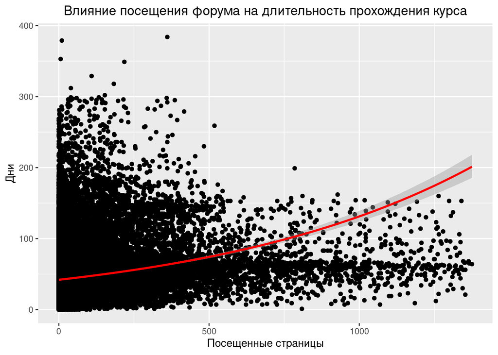

```r
students %>%
  ggplot(aes(y = duration, x = vis_p)) + geom_point() +  geom_smooth(method="glm.nb", color = "red") + ggtitle("Влияние посещения форума на длительность прохождения курса") + labs(x="Посещенные страницы", y = "Дни") +  theme(plot.title = element_text(hjust = 0.5))
```

## 2. Дисперсия посещения среди разных курсов

Почему используем НБ регрессию: потому что среднее меньше отклоенения

### Дисперсия длительности

```r
students %>% summarise(mean = mean(duration), variance = var(duration))
```

```
## # A tibble: 1 x 2
##    mean variance
##   <dbl>    <dbl>
## 1  46.1    1775.
```

```r
m0 <- glmer.nb(duration ~ 1 + (1|course_id), students)
summary(m0)
```

```
## Generalized linear mixed model fit by maximum likelihood (Laplace
##   Approximation) [glmerMod]
##  Family: Negative Binomial(1.2994)  ( log )
## Formula: duration ~ 1 + (1 | course_id)
##    Data: students
##
##       AIC       BIC    logLik  deviance  df.resid
##  464080.4  464106.9 -232037.2  464074.4     49896
##
## Scaled residuals:
##     Min      1Q  Median      3Q     Max
## -1.1321 -0.6532 -0.1479  0.3649  5.6808
##
## Random effects:
##  Groups    Name        Variance Std.Dev.
##  course_id (Intercept) 0.4256   0.6524
## Number of obs: 49899, groups:  course_id, 60
##
## Fixed effects:
##             Estimate Std. Error z value Pr(>|z|)
## (Intercept)  3.74582    0.08323   45.01   <2e-16 ***
## ---
## Signif. codes:  0 '***' 0.001 '**' 0.01 '*' 0.05 '.' 0.1 ' ' 1
```

```
## Средняя длительность прохождения курса - 42.34 (доверительный интервал 22.05-81.31, SD = 1.92) дней.
```

### Дисперсия посещений

```
## Generalized linear mixed model fit by maximum likelihood (Laplace
##   Approximation) [glmerMod]
##  Family: Negative Binomial(0.3979)  ( log )
## Formula: vis_p ~ 1 + (1 | course_id)
##    Data: students
##
##       AIC       BIC    logLik  deviance  df.resid
##  319250.0  319276.2 -159622.0  319244.0     45219
##
## Scaled residuals:
##     Min      1Q  Median      3Q     Max
## -0.6304 -0.5791 -0.3764  0.2451  7.0015
##
## Random effects:
##  Groups    Name        Variance Std.Dev.
##  course_id (Intercept) 4.291    2.071
## Number of obs: 45222, groups:  course_id, 60
##
## Fixed effects:
##             Estimate Std. Error z value Pr(>|z|)
## (Intercept)   2.0827     0.2589   8.043 8.75e-16 ***
## ---
## Signif. codes:  0 '***' 0.001 '**' 0.01 '*' 0.05 '.' 0.1 ' ' 1
```

[output not shown]

```r
students %>% group_by(course_id) %>% summarize(mean_vis = mean(vis_p, na.rm = TRUE), mean_dur = mean(duration, na.rm = TRUE)) %>% summarise(sd_vis = sd(mean_vis), sd_dur = sd(mean_dur))
```

```
## # A tibble: 1 x 2
##   sd_vis sd_dur
##    <dbl>  <dbl>
## 1   82.5   32.7
```

## 3. Влияние количества посещенных страниц на длительность прохождения курса со случайным свободным членом

```r
m1 <- glmer.nb(duration ~ vis_p_n + (1|course_id), students)
summary(m1)
```

```
## Generalized linear mixed model fit by maximum likelihood (Laplace
##   Approximation) [glmerMod]
##  Family: Negative Binomial(1.2776)  ( log )
## Formula: duration ~ vis_p_n + (1 | course_id)
##    Data: students
##
##       AIC       BIC    logLik  deviance  df.resid
##  419473.6  419508.5 -209732.8  419465.6     45218
##
## Scaled residuals:
##     Min      1Q  Median      3Q     Max
## -1.1219 -0.6585 -0.1572  0.3676  9.3202
##
## Random effects:
##  Groups    Name        Variance Std.Dev.
##  course_id (Intercept) 0.4675   0.6838
## Number of obs: 45222, groups:  course_id, 60
##
## Fixed effects:
##             Estimate Std. Error z value Pr(>|z|)
## (Intercept) 3.666023   0.088347   41.50   <2e-16 ***
## vis_p_n     0.054453   0.002854   19.08   <2e-16 ***
## ---
## Signif. codes:  0 '***' 0.001 '**' 0.01 '*' 0.05 '.' 0.1 ' ' 1
##
## Correlation of Fixed Effects:
##         (Intr)
## vis_p_n -0.031
```

```r
tab_model(m1)
```

|  | duration |  |  |
| --- | --- | --- | --- |
| Predictors | Incidence Rate Ratios | CI | p |
| (Intercept) | 39.10 | 32.88 – 46.49 | **<0.001** |
| vis_p_n | 1.06 | 1.05 – 1.06 | **<0.001** |
| Random Effects |  |  |  |
| σ<sup>2</sup> | 0.59 |  |  |
| τ<sub>00</sub> <sub>course_id</sub> | 0.47 |  |  |
| ICC | 0.44 |  |  |
| N <sub>course_id</sub> | 60 |  |  |
| Observations | 45222 |  |  |
| Marginal R<sup>2</sup> / Conditional R<sup>2</sup> | 0.007 / 0.445 |  |  |

[output not shown]

```
## Человек, который совершил 1 нормализованное посещение форума закончил курс за 41.28 дней.
```

```
## Человек, который совершил 10 нормализованных посещений форума закончил курс за 67.39 дней.
```

```
## Человек, который совершил 20 нормализованных посещений форума закончил курс за 116.17 дней.
##
```

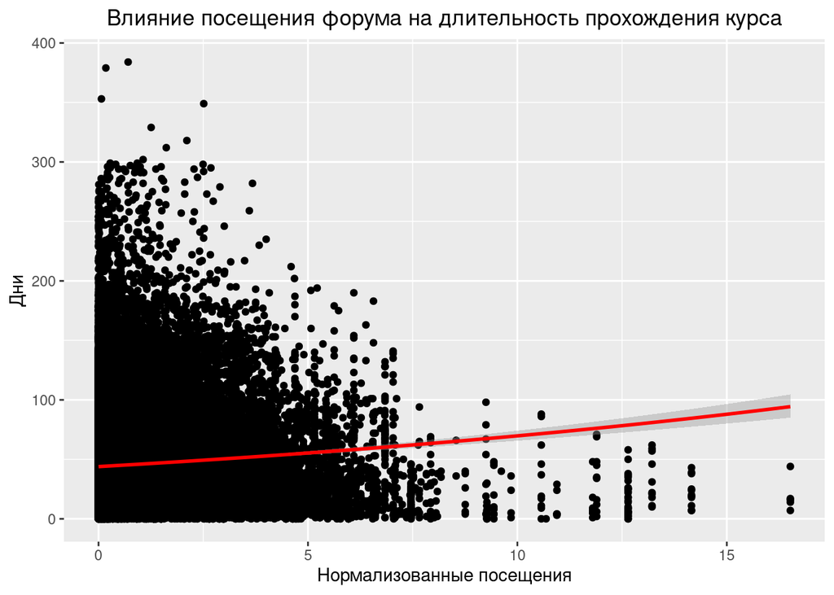

```r
students %>% filter(vis_p_n <20 ) %>%
  ggplot(aes(y = duration, x = vis_p_n)) + geom_point() +  geom_smooth(method="glm.nb", color = "red") + ggtitle("Влияние посещения форума на длительность прохождения курса") + labs(x="Нормализованные посещения", y = "Дни") +  theme(plot.title = element_text(hjust = 0.5))
```

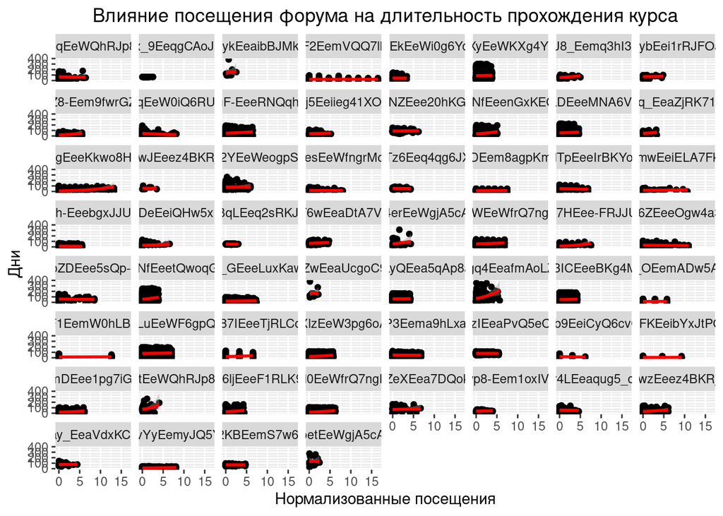

```r
students %>% filter(vis_p_n <20 ) %>%
  ggplot(aes(y = duration, x = vis_p_n)) + geom_point() +  geom_smooth(method="glm.nb", color = "red") + ggtitle("Влияние посещения форума на длительность прохождения курса") + labs(x="Нормализованные посещения", y = "Дни") +  theme(plot.title = element_text(hjust = 0.5)) + facet_wrap(~course_id)
```

## Means

```r
students_short <- students %>% group_by(course_slug) %>% summarise(vis_mean = round(mean(vis_p, na.rm =TRUE)), duration_mean = round(mean(duration, na.rm =TRUE), digits = 2))
```

```r
m2 <- lm(duration_mean ~ vis_mean, students_short)
summary(m2)
```

```
##
## Call:
## lm(formula = duration_mean ~ vis_mean, data = students_short)
##
## Residuals:
##     Min      1Q  Median      3Q     Max
## -45.635 -21.045  -5.284  14.122 113.484
##
## Coefficients:
##             Estimate Std. Error t value Pr(>|t|)
## (Intercept) 43.71877    4.09322  10.681 2.55e-15 ***
## vis_mean     0.20400    0.04458   4.576 2.55e-05 ***
## ---
## Signif. codes:  0 '***' 0.001 '**' 0.01 '*' 0.05 '.' 0.1 ' ' 1
##
## Residual standard error: 28.24 on 58 degrees of freedom
## Multiple R-squared:  0.2653, Adjusted R-squared:  0.2526
## F-statistic: 20.94 on 1 and 58 DF,  p-value: 2.546e-05
```

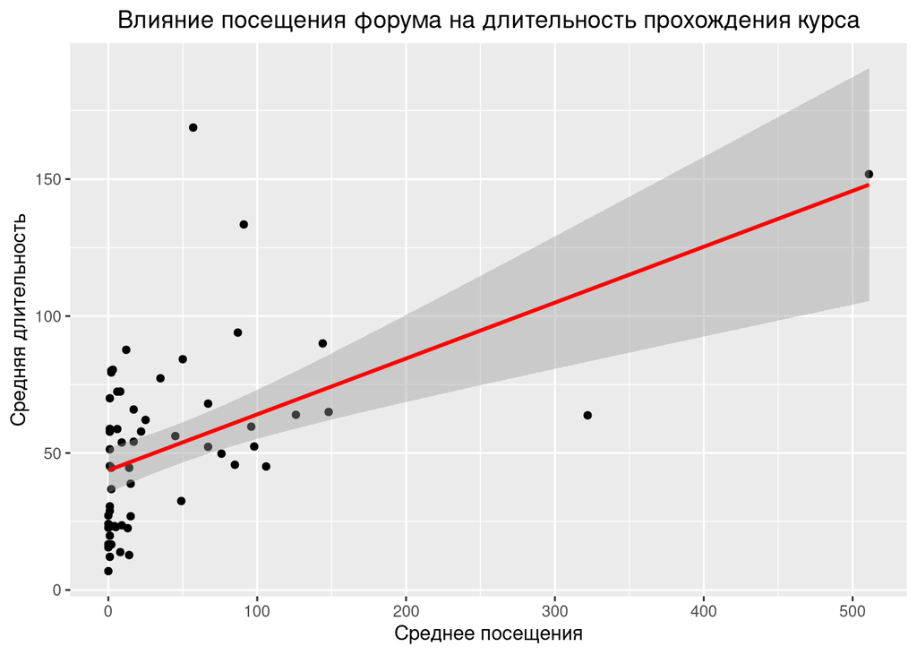

```r
students_short  %>%
  ggplot(aes(y = duration_mean, x = vis_mean)) + geom_point() +  geom_smooth(method="lm",color = "red") + ggtitle("Влияние посещения форума на длительность прохождения курса") + labs(x="Среднее посещения", y = "Средняя длительность") +  theme(plot.title = element_text(hjust = 0.5))
```

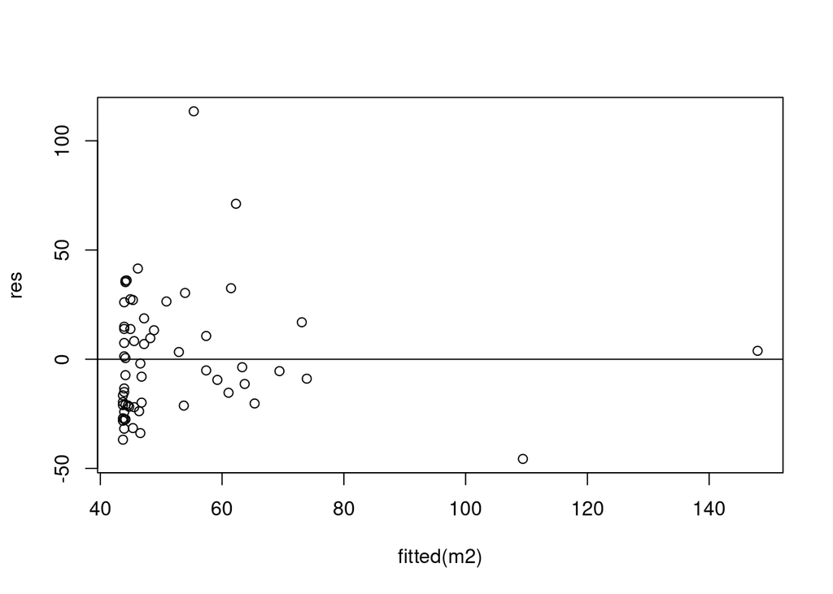

```r
res <- resid(m2)
plot(fitted(m2), res)
abline(0,0)
```

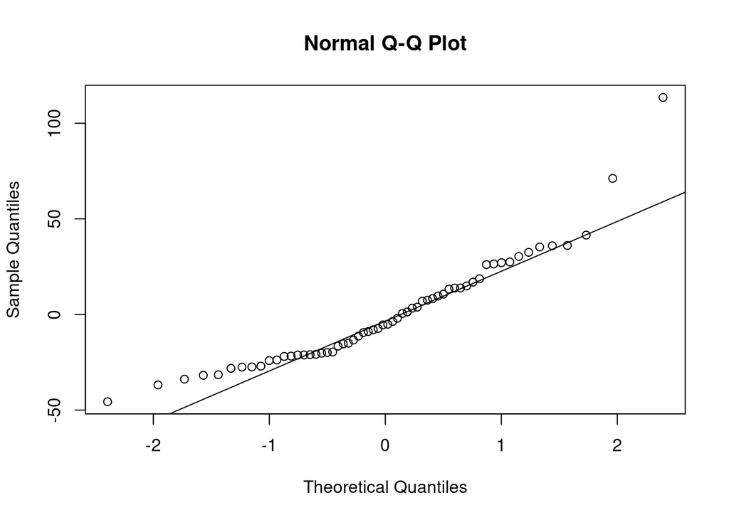

```r
qqnorm(res)
qqline(res)
```

```r
m2 <- lm(duration_mean ~ remove_outliers(vis_mean), students_short)
summary(m2)
```

```
##
## Call:
## lm(formula = duration_mean ~ remove_outliers(vis_mean), data = students_short)
##
## Residuals:
##     Min      1Q  Median      3Q     Max
## -34.460 -21.190  -8.509  17.469 107.468
##
## Coefficients:
##                           Estimate Std. Error t value Pr(>|t|)
## (Intercept)                40.2050     4.6032   8.734 6.56e-12 ***
## remove_outliers(vis_mean)   0.3712     0.1098   3.381  0.00135 **
## ---
## Signif. codes:  0 '***' 0.001 '**' 0.01 '*' 0.05 '.' 0.1 ' ' 1
##
## Residual standard error: 27.88 on 54 degrees of freedom
##   (4 observations deleted due to missingness)
## Multiple R-squared:  0.1747, Adjusted R-squared:  0.1594
## F-statistic: 11.43 on 1 and 54 DF,  p-value: 0.001349
```

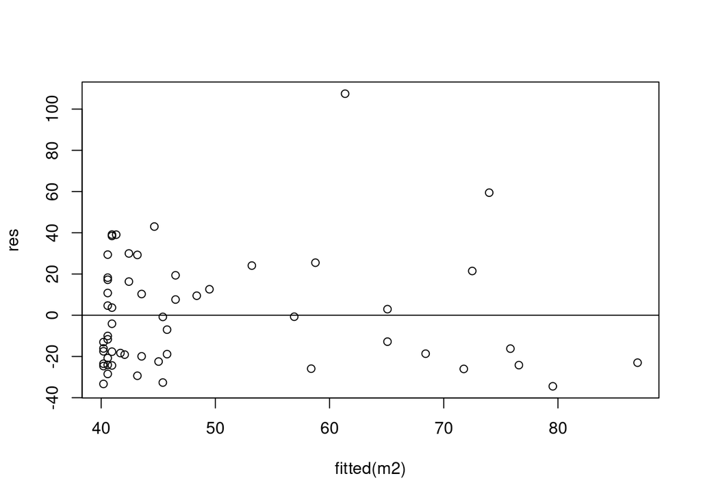

```r
res <- resid(m2)
plot(fitted(m2), res)
abline(0,0)
```

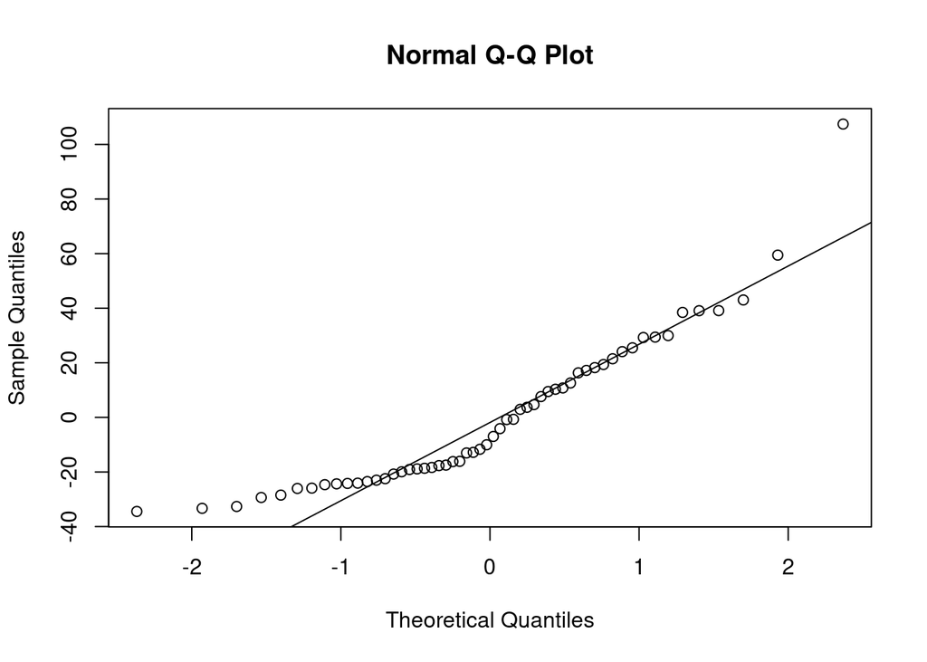

```r
qqnorm(res)
qqline(res)
```

## Выводы

[output not shown]